# Regression Models for Count Data DrPH (Epidemiology Speciality)

Kamarul Imran Musa Assoc Prof (Epidemiology and Statistics

2020-04-19

# 1 Introduction

The number of times an event can occur is a common form of data.

# 2 Motivation

Because the outcome is count, the popular model is Poisson regression.

Sometimes, the parameter $\mu$ is described as rate. The rate parameter is defined many ways (always in time frame):

- rate per year
- rate per season
- person-years

For this lecture, we deal with count not rate

# 3 Model

in Poisson regression, if Y is is the number of occurence, the probability distribution is written as
$$f(y) = \frac{\mu^y e^{-\mu}}{y!}$$
where $\mu$ is the average number of occurence. It can be shown that $E(Y) = \mu$ and $var(Y)=\mu$

# 4 Data

Usually data come in aggregated forms

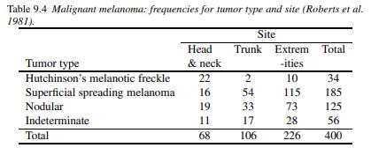

Table 9.4 Dobson

Source: An Introduction to Generalized Linear Models

The question of interest is whether there is any association between tumor type and site. The expected value of $Y_{jk}$ is

$$E(Y_{jk})= \mu_{jk} = n\theta_{jk}$$

The usual link function for Poisson model gives

$$log \, \mu_{jk}=log \, n + log \, \theta_{jk}$$

and the term $log \, n$ is the same for all the $Y_{jk}$

# 5 R codes

The saturated model

````
```{r}
ressat.melanoma<-glm(frequency~site*tumor,family=poisson(),
data=melanoma
```
````

The additive model

````
```{r}
resadd.melanoma<-glm(frequency~site + tumor,family=poisson(),
data=melanoma)
```
````

The minimal model

````
```{r}
resmin.melanoma<-glm(frequency~1, family=poisson(),
data=melanoma)
```
````

# 6 Interpretation

Let us say the result for the analysis is

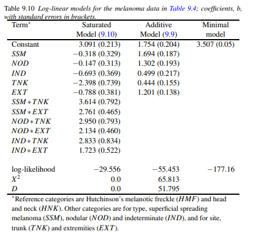

Table 9-10

Where the reference are the Melanonic freckle (HMF) on head or neck (HNK)

The expected frequencies for HMF on HNK for

- the minimal model $=\exp^{3.507}= 33.35$
- the additive model $=\exp^{1.754}= 5.78$
- the saturated model $=\exp^{3.091}= 22$

The expected frequencies for indeterminate tumours (IND) in the extremeties (EXT) for

- the minimal model $=\exp^{3.507}= 33.35$
- the additive model $=\exp^{1.754 + 0.499 + 1.201}= 31.64$
- the saturated model $=\exp^{3.091 - 0.693 - 0.788 + 1.723}= 28$

# 7 Model assessment

## 7.1 Measures

We can examine

- Pearson residuals
- Deviance residuals

## 7.2 Assessment

Measures to assess includes

- Goodness of fit $\chi^2$
- Deviance, $D$

# 8 References

- Annette J Dobson, Adrian G Barnett. An introduction to Generalized Linear Models. CRC Press
- https://www3.nd.edu/~rwilliam/stats3/CountModels.pdf